# Manipulating Data with dplyr

## Overview

[**dplyr**](https://cran.r-project.org/web/packages/dplyr/index.html) is an R package for working with structured data both in and outside of R. dplyr makes data manipulation for R users easy, consistent, and performant. With dplyr as an interface to manipulating Spark DataFrames, you can:

- Select, filter, and aggregate data
- Use window functions (e.g. for sampling)
- Perform joins on DataFrames
- Collect data from Spark into R

Statements in dplyr can be chained together using pipes defined by the [magrittr](https://cran.r-project.org/web/packages/magrittr/vignettes/magrittr.html) R package. dplyr also supports [non-standard evalution](https://cran.r-project.org/web/packages/dplyr/vignettes/nse.html) of its arguments. For more information on dplyr, see the [introduction](https://cran.r-project.org/web/packages/dplyr/vignettes/introduction.html), a guide for connecting to [databases](https://cran.r-project.org/web/packages/dplyr/vignettes/databases.html), and a variety of [vignettes](https://cran.r-project.org/web/packages/dplyr/index.html).

## Reading Data

You can read data into Spark DataFrames using the following functions:

| Function | Description |
| --- | --- |
| `spark_read_csv` | Reads a CSV file and provides a data source compatible with dplyr |
| `spark_read_json` | Reads a JSON file and provides a data source compatible with dplyr |
| `spark_read_parquet` | Reads a parquet file and provides a data source compatible with dplyr |

Regardless of the format of your data, Spark supports reading data from a variety of different data sources. These include data stored on HDFS (`hdfs://` protocol), Amazon S3 (`s3n://` protocol), or local files available to the Spark worker nodes (`file://` protocol)

Each of these functions returns a reference to a Spark DataFrame which can be used as a dplyr table (`tbl`).

### Flights Data

This guide will demonstrate some of the basic data manipulation verbs of dplyr by using data from the `nycflights13` R package. This package contains data for all 336,776 flights departing New York City in 2013. It also includes useful metadata on airlines, airports, weather, and planes. The data comes from the US [Bureau of Transportation Statistics](http://www.transtats.bts.gov/DatabaseInfo.asp?DB_ID=120&Link=0), and is documented in `?nycflights13`

Connect to the cluster and copy the flights data using the `copy_to` function. Caveat: The flight data in `nycflights13` is convenient for dplyr demonstrations because it is small, but in practice large data should rarely be copied directly from R objects.

```r
library(sparklyr)
library(dplyr)
library(nycflights13)
library(ggplot2)
sc <- spark_connect(master = "local", version = "2.0.0", hadoop_version="2.7")
flights <- copy_to(sc, flights, "flights")
airlines <- copy_to(sc, airlines, "airlines")
src_tbls(sc)
```

```
[1] "airlines" "flights"
```

## dplyr Verbs

Verbs are dplyr commands for manipulating data. When connected to a Spark DataFrame, dplyr translates the commands into Spark SQL statements. Remote data sources use exactly the same five verbs as local data sources. Here are the five verbs with their corresponding SQL commands:

- `select` ~ `SELECT`
- `filter` ~ `WHERE`
- `arrange` ~ `ORDER`
- `summarise` ~ `aggregators: sum, min, sd, etc.`
- `mutate` ~ `operators: +, *, log, etc.`

```r
mutate(flights, speed = distance / air_time * 60)
```

```
Source:   query [?? x 20]
Database: spark connection master=local[4] app=sparklyr local=TRUE

    year month   day dep_time sched_dep_time dep_delay arr_time sched_arr_time arr_delay carrier
   <int> <int> <int>    <int>          <int>     <dbl>    <int>          <int>     <dbl>   <chr>
1   2013     1     1      517            515         2      830            819        11      UA
2   2013     1     1      533            529         4      850            830        20      UA
3   2013     1     1      542            540         2      923            850        33      AA
4   2013     1     1      544            545        -1     1004           1022       -18      B6
5   2013     1     1      554            600        -6      812            837       -25      DL
6   2013     1     1      554            558        -4      740            728        12      UA
7   2013     1     1      555            600        -5      913            854        19      B6
8   2013     1     1      557            600        -3      709            723       -14      EV
9   2013     1     1      557            600        -3      838            846        -8      B6
10  2013     1     1      558            600        -2      753            745         8      AA
# ... with more rows, and 10 more variables: flight <int>, tailnum <chr>, origin <chr>,
#   dest <chr>, air_time <dbl>, distance <dbl>, hour <dbl>, minute <dbl>, time_hour <dbl>,
#   speed <dbl>
```

## Laziness

When working with databases, dplyr tries to be as lazy as possible:

- It never pulls data into R unless you explicitly ask for it.
- It delays doing any work until the last possible moment: it collects together everything you want to do and then sends it to the database in one step.

For example, take the following code:

```r
c1 <- filter(flights, day == 17, month == 5, carrier %in% c('UA', 'WN', 'AA', 'DL'))
c2 <- select(c1, year, month, day, carrier, dep_delay, air_time, distance)
c3 <- arrange(c2, year, month, day, carrier)
c4 <- mutate(c3, air_time_hours = air_time / 60)
```

This sequence of operations never actually touches the database. It’s not until you ask for the data (e.g. by printing `c4`) that dplyr requests the results from the database.

```r
c4
```

```
Source:   query [?? x 8]
Database: spark connection master=local[4] app=sparklyr local=TRUE

    year month   day carrier dep_delay air_time distance air_time_hours
   <int> <int> <int>   <chr>     <dbl>    <dbl>    <dbl>          <dbl>
1   2013     5    17      AA        -2      294     2248       4.900000
2   2013     5    17      AA        -1      146     1096       2.433333
3   2013     5    17      AA        -2      185     1372       3.083333
4   2013     5    17      AA        -9      186     1389       3.100000
5   2013     5    17      AA         2      147     1096       2.450000
6   2013     5    17      AA        -4      114      733       1.900000
7   2013     5    17      AA        -7      117      733       1.950000
8   2013     5    17      AA        -7      142     1089       2.366667
9   2013     5    17      AA        -6      148     1089       2.466667
10  2013     5    17      AA        -7      137      944       2.283333
# ... with more rows
```

## Piping

You can use [magrittr](https://cran.r-project.org/web/packages/magrittr/vignettes/magrittr.html) pipes to write cleaner syntax. Using the same example from above, you can write a much cleaner version like this:

```r
c4 <- flights %>%
  filter(month == 5, day == 17, carrier %in% c('UA', 'WN', 'AA', 'DL')) %>%
  select(carrier, dep_delay, air_time, distance) %>%
  arrange(carrier) %>%
  mutate(air_time_hours = air_time / 60)
```

## Grouping

The `group_by` function corresponds to the `GROUP BY` statement in SQL.

```r
c4 %>%
  group_by(carrier) %>%
  summarize(count = n(), mean_dep_delay = mean(dep_delay))
```

```
Source:   query [?? x 3]
Database: spark connection master=local[4] app=sparklyr local=TRUE

  carrier     count mean_dep_delay
    <chr>    <list>          <dbl>
1      AA <dbl [1]>       1.468085
2      DL <dbl [1]>       6.235294
3      UA <dbl [1]>       9.633721
4      WN <dbl [1]>       7.970588
```

## Collecting to R

You can copy data from Spark into R’s memory by using `collect()`.

```r
carrierhours <- collect(c4)
```

`collect()` executes the Spark query and returns the results to R for further analysis and visualization.

```r
# Test the significance of pairwise differences and plot the results
with(carrierhours, pairwise.t.test(air_time, carrier))
```

```
    Pairwise comparisons using t tests with pooled SD

data:  air_time and carrier

   AA      DL      UA
DL 0.25057 -       -
UA 0.07957 0.00044 -
WN 0.07957 0.23488 0.00041

P value adjustment method: holm
```

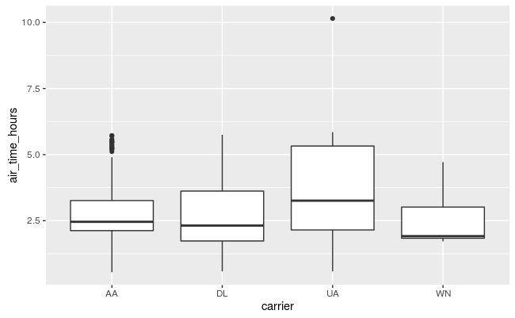

```r
ggplot(carrierhours, aes(carrier, air_time_hours)) + geom_boxplot()
```

If you want to execute a query and store the results in a temporary table, use `compute()`

```r
compute(c4, 'carrierhours')
src_tbls(sc)
```

## SQL Translation

When doing simple mathematical operations of the form you normally use when filtering, mutating and summarizing it’s relatively straightforward to translate R code to SQL (or indeed to any programming language). dplyr knows how to convert the following R functions to Spark SQL:

```
# Basic math operators
+, -, *, /, %%, ^

# Math functions
abs, acos, asin, asinh, atan, atan2, ceiling, cos, cosh, exp, floor, log, log10, round, sign, sin, sinh, sqrt, tan, tanh

# Logical comparisons
<, <=, !=, >=, >, ==, %in%

# Boolean operations
&, &&, |, ||, !

# Basic aggregations
mean, sum, min, max
```

## Window Functions

dplyr supports Spark SQL window functions. Window functions are used in conjunction with mutate and filter to solve a wide range of problems. You can compare the dplyr syntax to the query it has generated by using `sql_render()`.

```r
# Find the most and least delayed flight each day
bestworst <- flights %>%
  group_by(year, month, day) %>%
  select(dep_delay) %>%
  filter(dep_delay == min(dep_delay) || dep_delay == max(dep_delay))
sql_render(bestworst)
```

```
<SQL> SELECT `year`, `month`, `day`, `dep_delay`
FROM (SELECT `year`, `month`, `day`, `dep_delay`, min(`dep_delay`) OVER (PARTITION BY `year`, `month`, `day`) AS `zzz4`, max(`dep_delay`) OVER (PARTITION BY `year`, `month`, `day`) AS `zzz5`
FROM (SELECT `year` AS `year`, `month` AS `month`, `day` AS `day`, `dep_delay` AS `dep_delay`
FROM `flights`) `pxuylwyopf`) `uswavkecpb`
WHERE (`dep_delay` = `zzz4` OR `dep_delay` = `zzz5`)
```

```r
bestworst
```

```
Source:   query [?? x 4]
Database: spark connection master=local[4] app=sparklyr local=TRUE
Groups: year, month, day

    year month   day dep_delay
   <int> <int> <int>     <dbl>
1   2013     1     1       853
2   2013     1     1       -15
3   2013     1     1       -15
4   2013     1     9      1301
5   2013     1     9       -17
6   2013     1    14       -20
7   2013     1    14       334
8   2013     1    23       -18
9   2013     1    23       478
10  2013     1    24       -15
# ... with more rows
```

```r
# Rank each flight within a daily
ranked <- flights %>%
  group_by(year, month, day) %>%
  select(dep_delay) %>%
  mutate(rank = rank(desc(dep_delay)))
sql_render(ranked)
```

```
<SQL> SELECT `year`, `month`, `day`, `dep_delay`, rank() OVER (PARTITION BY `year`, `month`, `day` ORDER BY `dep_delay` DESC) AS `rank`
FROM (SELECT `year` AS `year`, `month` AS `month`, `day` AS `day`, `dep_delay` AS `dep_delay`
FROM `flights`) `rkbuwaeirq`
```

```r
ranked
```

```
Source:   query [?? x 5]
Database: spark connection master=local[4] app=sparklyr local=TRUE
Groups: year, month, day

    year month   day dep_delay  rank
   <int> <int> <int>     <dbl> <int>
1   2013     1     1       853     1
2   2013     1     1       379     2
3   2013     1     1       290     3
4   2013     1     1       285     4
5   2013     1     1       260     5
6   2013     1     1       255     6
7   2013     1     1       216     7
8   2013     1     1       192     8
9   2013     1     1       157     9
10  2013     1     1       155    10
# ... with more rows
```

## Peforming Joins

It’s rare that a data analysis involves only a single table of data. In practice, you’ll normally have many tables that contribute to an analysis, and you need flexible tools to combine them. In dplyr, there are three families of verbs that work with two tables at a time:

- Mutating joins, which add new variables to one table from matching rows in another.
- Filtering joins, which filter observations from one table based on whether or not they match an observation in the other table.
- Set operations, which combine the observations in the data sets as if they were set elements.

All two-table verbs work similarly. The first two arguments are `x` and `y`, and provide the tables to combine. The output is always a new table with the same type as `x`.

The following statements are equivalent:

```r
flights %>% inner_join(airlines)
```

```
Source:   query [?? x 20]
Database: spark connection master=local[4] app=sparklyr local=TRUE

   carrier  year month   day dep_time sched_dep_time dep_delay arr_time sched_arr_time arr_delay
     <chr> <int> <int> <int>    <int>          <int>     <dbl>    <int>          <int>     <dbl>
1       UA  2013     1     1      517            515         2      830            819        11
2       UA  2013     1     1      533            529         4      850            830        20
3       AA  2013     1     1      542            540         2      923            850        33
4       B6  2013     1     1      544            545        -1     1004           1022       -18
5       DL  2013     1     1      554            600        -6      812            837       -25
6       UA  2013     1     1      554            558        -4      740            728        12
7       B6  2013     1     1      555            600        -5      913            854        19
8       EV  2013     1     1      557            600        -3      709            723       -14
9       B6  2013     1     1      557            600        -3      838            846        -8
10      AA  2013     1     1      558            600        -2      753            745         8
# ... with more rows, and 10 more variables: flight <int>, tailnum <chr>, origin <chr>,
#   dest <chr>, air_time <dbl>, distance <dbl>, hour <dbl>, minute <dbl>, time_hour <dbl>,
#   name <chr>
```

```r
flights %>% inner_join(airlines, by = "carrier")
```

```
Source:   query [?? x 20]
Database: spark connection master=local[4] app=sparklyr local=TRUE

   carrier  year month   day dep_time sched_dep_time dep_delay arr_time sched_arr_time arr_delay
     <chr> <int> <int> <int>    <int>          <int>     <dbl>    <int>          <int>     <dbl>
1       UA  2013     1     1      517            515         2      830            819        11
2       UA  2013     1     1      533            529         4      850            830        20
3       AA  2013     1     1      542            540         2      923            850        33
4       B6  2013     1     1      544            545        -1     1004           1022       -18
5       DL  2013     1     1      554            600        -6      812            837       -25
6       UA  2013     1     1      554            558        -4      740            728        12
7       B6  2013     1     1      555            600        -5      913            854        19
8       EV  2013     1     1      557            600        -3      709            723       -14
9       B6  2013     1     1      557            600        -3      838            846        -8
10      AA  2013     1     1      558            600        -2      753            745         8
# ... with more rows, and 10 more variables: flight <int>, tailnum <chr>, origin <chr>,
#   dest <chr>, air_time <dbl>, distance <dbl>, hour <dbl>, minute <dbl>, time_hour <dbl>,
#   name <chr>
```

```r
flights %>% inner_join(airlines, by = c("carrier" = "carrier"))
```

```
Source:   query [?? x 20]
Database: spark connection master=local[4] app=sparklyr local=TRUE

   carrier  year month   day dep_time sched_dep_time dep_delay arr_time sched_arr_time arr_delay
     <chr> <int> <int> <int>    <int>          <int>     <dbl>    <int>          <int>     <dbl>
1       UA  2013     1     1      517            515         2      830            819        11
2       UA  2013     1     1      533            529         4      850            830        20
3       AA  2013     1     1      542            540         2      923            850        33
4       B6  2013     1     1      544            545        -1     1004           1022       -18
5       DL  2013     1     1      554            600        -6      812            837       -25
6       UA  2013     1     1      554            558        -4      740            728        12
7       B6  2013     1     1      555            600        -5      913            854        19
8       EV  2013     1     1      557            600        -3      709            723       -14
9       B6  2013     1     1      557            600        -3      838            846        -8
10      AA  2013     1     1      558            600        -2      753            745         8
# ... with more rows, and 10 more variables: flight <int>, tailnum <chr>, origin <chr>,
#   dest <chr>, air_time <dbl>, distance <dbl>, hour <dbl>, minute <dbl>, time_hour <dbl>,
#   name <chr>
```

## Sampling

You can use `sdf_sample` to take a random sample of rows.

```r
sdf_sample(flights, 0.01)
```

```
Source:   query [?? x 19]
Database: spark connection master=local[4] app=sparklyr local=TRUE

    year month   day dep_time sched_dep_time dep_delay arr_time sched_arr_time arr_delay carrier
   <int> <int> <int>    <int>          <int>     <dbl>    <int>          <int>     <dbl>   <chr>
1   2013     1     1      904            906        -2     1207           1226       -19      UA
2   2013     1     1     1047           1055        -8     1359           1405        -6      AA
3   2013     1     1     1255           1259        -4     1501           1502        -1      US
4   2013     1     1     1317           1325        -8     1454           1505       -11      MQ
5   2013     1     1     1602           1605        -3     1834           1838        -4      DL
6   2013     1     1     1607           1555        12     1735           1715        20      B6
7   2013     1     1     1941           1940         1     2231           2241       -10      B6
8   2013     1     2      757            800        -3     1058           1127       -29      DL
9   2013     1     2      919            920        -1     1240           1245        -5      AA
10  2013     1     2     1014           1010         4     1128           1140       -12      MQ
# ... with more rows, and 9 more variables: flight <int>, tailnum <chr>, origin <chr>,
#   dest <chr>, air_time <dbl>, distance <dbl>, hour <dbl>, minute <dbl>, time_hour <dbl>
```

## Writing Data

It is often useful to save the results of your analysis or the tables that you have generated on your Spark cluster into persistent storage. The best option in many scenarios is to write the table out to a [Parquet](https://parquet.apache.org/) file using the spark_write_parquet function. For example:

```r
spark_write_parquet(flights, "nycflights13/parquet2")
```

This will write the Spark DataFrame referenced by the tbl R variable to the given HDFS path. You can use the spark_read_parquet function to read the same table back into a subsequent Spark session:

```r
spark_read_parquet(sc, "data", "nycflights13/parquet2")
```

You can also write data as CSV or JSON using the spark_write_csv and spark_write_json functions.